# Practical 1 Repeated Measurements

## Practical 1: Marginal Models for Continuous Data

We start by loading the packages we will need for this practical and the data from [GitHub](https://github.com/drizopoulos/Repeated_Measurements). This is achieved with the following commands:

```r
# packages
library("lattice")
library("nlme")
library("splines")

# data
con <- url("https://raw.github.com/drizopoulos/Repeated_Measurements/master/Data.RData")
load(con)
close(con)
```

### Question 1

We produce the plot of the subject-specific trajectories separately per treatment group with a superimposed loess curve. This achieved with the following call to function [xyplot()](https://goo.gl/cGSjZk):

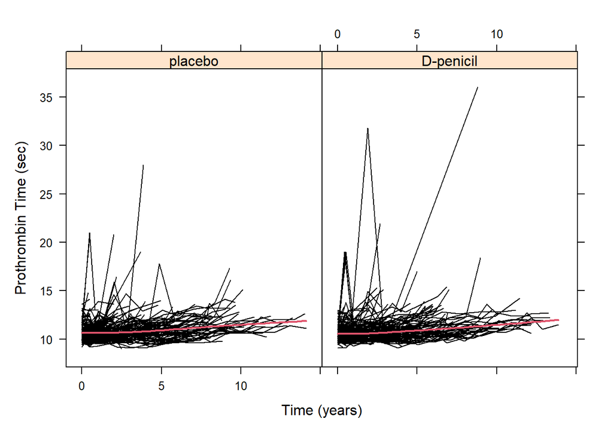

```r
xyplot(prothrombin ~ year | drug, group = id, data = pbc2,
       panel = function (x, y, ...) {
           panel.xyplot(x, y, type = "l", col = 1, ...)
           panel.loess(x, y, col = 2, lwd = 2)
       }, xlab = "Time (years)", ylab = "Prothrombin Time (sec)")
```

With virtually an analogous call to [xyplot()](https://goo.gl/cGSjZk) we also produce the plot of the subject-specific trajectories per sex:

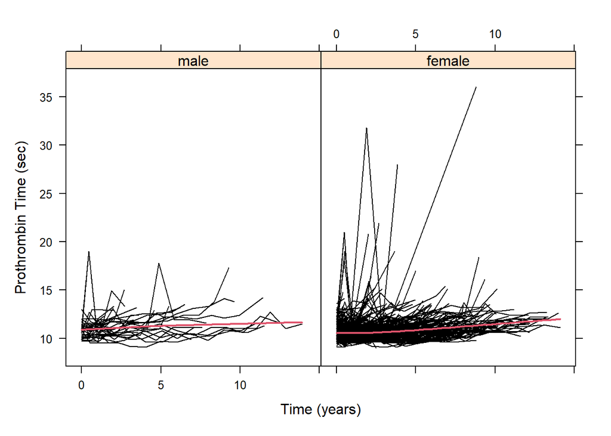

```r
xyplot(prothrombin ~ year | sex, group = id, data = pbc2,
       panel = function (x, y, ...) {
           panel.xyplot(x, y, type = "l", col = 1, ...)
           panel.loess(x, y, col = 2, lwd = 2)
       }, xlab = "Time (years)", ylab = "Prothrombin Time (sec)")
```

From both plots we observe that we have some outlying measurements that affect the scale of the y-axis. We could zoom in by specifying the `ylim` argument, e.g.,

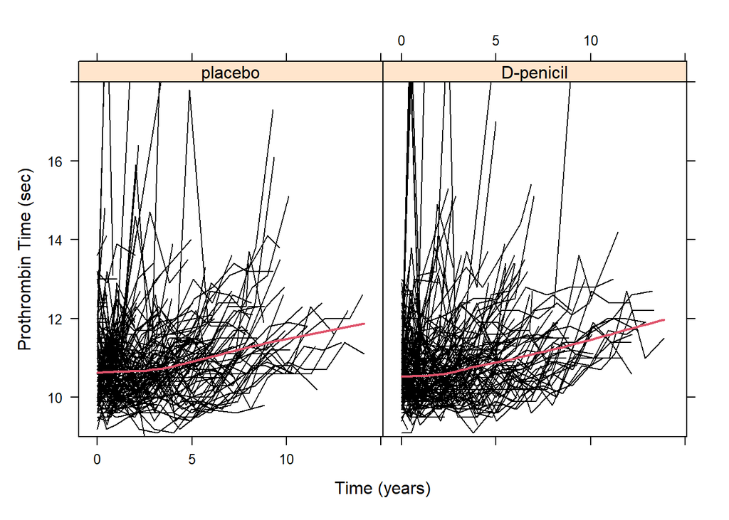

```r
xyplot(prothrombin ~ year | drug, group = id, data = pbc2,
       panel = function (x, y, ...) {
           panel.xyplot(x, y, type = "l", col = 1, ...)
           panel.loess(x, y, col = 2, lwd = 2)
       }, xlab = "Time (years)", ylab = "Prothrombin Time (sec)",
       ylim = c(9, 18))
```

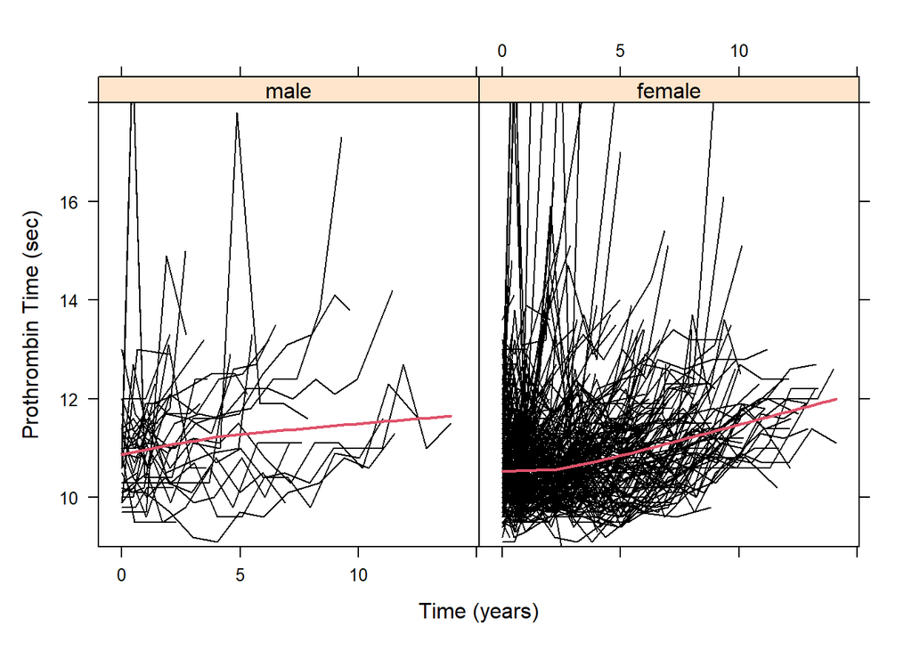

```r
xyplot(prothrombin ~ year | sex, group = id, data = pbc2,
       panel = function (x, y, ...) {
           panel.xyplot(x, y, type = "l", col = 1, ...)
           panel.loess(x, y, col = 2, lwd = 2)
       }, xlab = "Time (years)", ylab = "Prothrombin Time (sec)",
       ylim = c(9, 18))
```

Some observations

- There is considerable variability in the profiles of prothrombin time.
- There is an overall increasing trend indicating worsening of the condition of the patients.
- No apparent differences can be seen between the two treatment groups, and between sexes.

**Remove Outliers:** The plots above show that some patients has extreme prothrombin times at some occasions; in order not to be affected by these outliers, for the remainder of this analysis we remove the 13 prothrombin times which were larger than 18 sec, i.e.,

```r
pbc2 <- pbc2[pbc2$prothrombin < 18, ]
```

### Question 2

A basic call to function [gls()](https://goo.gl/0KBq4B) without specifying a correlation structure (i.e., argument `correlation`) or a variance function (i.e., argument `weights`) fits a simple linear regression model (i.e., it is equivalent to [lm()](https://goo.gl/tewND3) and postulates that the repeated measurements of each patient are uncorrelated). To include the natural cubic splines of time with 3 degrees of freedom we need use function [ns()](https://goo.gl/0g115B). As mentioned in Section 2.4, it is advisable to set the boundary knots to the 5% and 95% percentiles of the visit times. To find these time points we use function [quantile()](https://goo.gl/e1krNy), i.e.,

```r
quantile(pbc2$year, probs = c(0, 0.05, 0.95, 1))
```

```
##        0%        5%       95%      100%
##  0.000000  0.000000  9.286497 14.105793
```

Hence, the call to [gls()](https://goo.gl/0KBq4B) that includes the nonlinear time effect, the main effect of age, sex and drug, and the interaction terms between the nonlinear time and sex and drug is:

```r
fm_1 <- gls(prothrombin ~ ns(year, 3, B = c(0, 9.3)) * (sex + drug) + age,
            data = pbc2)

summary(fm_1)
```

```
## Generalized least squares fit by REML
##   Model: prothrombin ~ ns(year, 3, B = c(0, 9.3)) * (sex + drug) + age
##   Data: pbc2
##        AIC      BIC    logLik
##   5527.208 5605.042 -2749.604
##
## Coefficients:
##                                               Value Std.Error  t-value p-value
## (Intercept)                               10.496946 0.2021156 51.93536  0.0000
## ns(year, 3, B = c(0, 9.3))1                0.311066 0.2761478  1.12645  0.2601
## ns(year, 3, B = c(0, 9.3))2                0.822796 0.3795720  2.16769  0.0303
## ns(year, 3, B = c(0, 9.3))3                0.748927 0.1930302  3.87985  0.0001
## sexfemale                                 -0.234711 0.1576605 -1.48871  0.1367
## drugD-penicil                             -0.139261 0.1001763 -1.39016  0.1646
## age                                        0.009539 0.0023193  4.11295  0.0000
## ns(year, 3, B = c(0, 9.3))1:sexfemale     -0.200237 0.2745163 -0.72942  0.4658
## ns(year, 3, B = c(0, 9.3))2:sexfemale     -0.267442 0.3754839 -0.71226  0.4764
## ns(year, 3, B = c(0, 9.3))3:sexfemale      0.060928 0.1929642  0.31575  0.7522
## ns(year, 3, B = c(0, 9.3))1:drugD-penicil  0.283071 0.1830545  1.54638  0.1222
## ns(year, 3, B = c(0, 9.3))2:drugD-penicil  0.121278 0.2440731  0.49689  0.6193
## ns(year, 3, B = c(0, 9.3))3:drugD-penicil  0.068573 0.1335474  0.51347  0.6077
##
##  Correlation:
##                                           (Intr) ns(,3,B=c(0,9.3))1
## ns(year, 3, B = c(0, 9.3))1               -0.128
## ns(year, 3, B = c(0, 9.3))2               -0.726  0.067
## ns(year, 3, B = c(0, 9.3))3               -0.215  0.328
## sexfemale                                 -0.754  0.133
## drugD-penicil                             -0.246  0.043
## age                                       -0.621  0.027
## ns(year, 3, B = c(0, 9.3))1:sexfemale      0.125 -0.881
## ns(year, 3, B = c(0, 9.3))2:sexfemale      0.643 -0.068
## ns(year, 3, B = c(0, 9.3))3:sexfemale      0.192 -0.314
## ns(year, 3, B = c(0, 9.3))1:drugD-penicil  0.031 -0.372
## ns(year, 3, B = c(0, 9.3))2:drugD-penicil  0.260 -0.001
## ns(year, 3, B = c(0, 9.3))3:drugD-penicil  0.050 -0.055
##                                           ns(,3,B=c(0,9.3))2 ns(,3,B=c(0,9.3))3
## ns(year, 3, B = c(0, 9.3))1
## ns(year, 3, B = c(0, 9.3))2
## ns(year, 3, B = c(0, 9.3))3                0.214
```

[output cut: 79 more lines]

```
## drugD-penicil
## age
## ns(year, 3, B = c(0, 9.3))1:sexfemale
## ns(year, 3, B = c(0, 9.3))2:sexfemale
## ns(year, 3, B = c(0, 9.3))3:sexfemale
## ns(year, 3, B = c(0, 9.3))1:drugD-penicil
## ns(year, 3, B = c(0, 9.3))2:drugD-penicil
## ns(year, 3, B = c(0, 9.3))3:drugD-penicil  0.225
##
## Standardized residuals:
##        Min         Q1        Med         Q3        Max
## -2.2301484 -0.7022815 -0.1508775  0.4456803  6.4146579
##
## Residual standard error: 0.9972037
## Degrees of freedom: 1932 total; 1919 residual
```

Interpretation of the results

- The terms that involve the spline coefficients (main of time and its interaction with sex and drug) do not have a straightforward interpretation. This is where the effect plots we have seen in Section 2.4 are of great use.
- The main effects of age, sex, and drug do have a meaningful interpretation. In particular:
  - The coefficient of age 0.0095 denotes the increase in prothrombin time per year increase in age for patients of the same sex and who receive the same drug, and are compared at the same follow-up time.
  - The coefficient of drug -0.14 denotes the difference in prothrombin time between the two treatment groups at baseline for patients of the same sex and age.

We should **not** simplify the model at this stage. As we have mentioned in Section 2.8, we should first decide on the covariance structure while keeping the mean structure as general as possible.

### Question 3

```r
fm_2 <- gls(prothrombin ~ ns(year, 3, B = c(0, 9.3)) * (sex + drug) + age,
            data = pbc2, correlation = corCompSymm(form = ~ year | id))

fm_3 <- gls(prothrombin ~ ns(year, 3, B = c(0, 9.3)) * (sex + drug) + age,
            data = pbc2, correlation = corCAR1(form = ~ year | id))

fm_4 <- gls(prothrombin ~ ns(year, 3, B = c(0, 9.3)) * (sex + drug) + age,
            data = pbc2, correlation = corLin(form = ~ year | id))

fm_5 <- gls(prothrombin ~ ns(year, 3, B = c(0, 9.3)) * (sex + drug) + age,
            data = pbc2, correlation = corGaus(form = ~ year | id))
```

The models above are homoscedastic, i.e., they assume constant variance for the error terms. To fit heteroscedastic marginal models we can utilize the `weights` argument of [gls()](https://goo.gl/0KBq4B). The following piece of code extends the models from above using the constructor function [varExp()](https://goo.gl/nOZBqT) that postulates that the variance of the error terms is an exponential function of time:

```r
fm_6 <- gls(prothrombin ~ ns(year, 3, B = c(0, 9.3)) * (sex + drug) + age,
            data = pbc2, correlation = corCompSymm(form = ~ year | id),
            weights = varExp(form = ~ year))

fm_7 <- gls(prothrombin ~ ns(year, 3, B = c(0, 9.3)) * (sex + drug) + age,
            data = pbc2, correlation = corCAR1(form = ~ year | id),
            weights = varExp(form = ~ year))

fm_8 <- gls(prothrombin ~ ns(year, 3, B = c(0, 9.3)) * (sex + drug) + age,
            data = pbc2, correlation = corLin(form = ~ year | id),
            weights = varExp(form = ~ year))

fm_9 <- gls(prothrombin ~ ns(year, 3, B = c(0, 9.3)) * (sex + drug) + age,
            data = pbc2, correlation = corGaus(form = ~ year | id),
            weights = varExp(form = ~ year))
```

### Question 4

First we should note that model `fm_1` that assumed uncorrelated and homoscedastic errors is nested in all other models we have fitted. If you perform the likelihood ratio test, and as we would expect, you will observe that the data do not support this model.

We start by comparing the four homoscedastic marginal models with the different correlation structures. These models are not nested and therefore we can only compare them using the information criteria AIC and BIC using the [anova()](https://goo.gl/RuqkSV) function:

```r
anova(fm_2, fm_3, fm_4, fm_5)
```

```
##      Model df      AIC      BIC    logLik
## fm_2     1 15 5017.446 5100.839 -2493.723
## fm_3     2 15 4844.597 4927.991 -2407.299
## fm_4     3 15 5024.317 5107.711 -2497.159
## fm_5     4 15 5273.814 5357.207 -2621.907
```

We observe that the continuous AR1 model `fm_3` has the lowest AIC and BIC values. Next we compare the heteroscedastic models:

```r
anova(fm_6, fm_7, fm_8, fm_9)
```

```
##      Model df      AIC      BIC    logLik
## fm_6     1 16 4991.579 5080.532 -2479.790
## fm_7     2 16 4844.257 4933.210 -2406.128
## fm_8     3 16 5145.139 5234.092 -2556.570
## fm_9     4 16 5275.233 5364.186 -2621.617
```

```r
anova(fm_3, fm_7)
```

```
##      Model df      AIC      BIC    logLik   Test  L.Ratio p-value
## fm_3     1 15 4844.597 4927.991 -2407.299
## fm_7     2 16 4844.257 4933.210 -2406.128 1 vs 2 2.340228  0.1261
```

The result suggests that the heteroscedastic continuous AR1 model does not provide a substantially better fit to the data. Hence, we continue the reminder of our analysis using model `fm_3`

### Question 5

We continue by testing whether we can drop all the interaction terms between the nonlinear time effect and sex, and the nonlinear time effect and drug. The corresponding model terms that we wish to test are `ns(year, 3, B = c(0, 9.3)):sex` and `ns(year, 3, B = c(0, 9.3)):drug`. Using the `Terms` argument of the [anova()](https://goo.gl/RuqkSV) function we perform the corresponding F-test as we have seen in Section 2.9:

```r
anova(fm_3, Terms = c('ns(year, 3, B = c(0, 9.3)):sex',
                      'ns(year, 3, B = c(0, 9.3)):drug'))
```

```
## Denom. DF: 1919
##  F-test for: ns(year, 3, B = c(0, 9.3)):sex, ns(year, 3, B = c(0, 9.3)):drug
##   numDF   F-value p-value
## 1     6 0.6233694  0.7117
```

The results indicate that average longitudinal evolutions of prothrombin time do not differ between males and female, and placebo and D-penicillamine patients. To test the same terms using a likelihood ratio test we need first to fit the model under the null hypothesis, i.e., the model that excludes these terms. The call to [gls()](https://goo.gl/0KBq4B) that fits this model is:

```r
fm_3_noInt <- gls(prothrombin ~ ns(year, 3, B = c(0, 9.3)) + sex + drug + age,
                  data = pbc2, correlation = corCAR1(form = ~ year | id))
```

To perform the likelihood ratio test we need to give the model under the null `fm_3_noInt` and the model under the alternative hypothesis `fm_3` to the [anova()](https://goo.gl/RuqkSV) function:

```r
anova(fm_3_noInt, fm_3)
```

```
## Warning in nlme::anova.lme(object = fm_3_noInt, fm_3): fitted objects with
## different fixed effects. REML comparisons are not meaningful.
```

```
##            Model df      AIC      BIC    logLik   Test   L.Ratio p-value
## fm_3_noInt     1  9 4831.730 4881.794 -2406.865
## fm_3           2 15 4844.597 4927.991 -2407.299 1 vs 2 0.8669753  0.9902
```

We obtain a result but also a **warning** message. In particular, as we have seen in Section 2.9, when we want to compare models that have different $X\beta$ with a likelihood ratio test, we need to fit the models using Maximum Likelihood (ML) and not Restricted Maximum Likelihood (REML). REML is the default method to fit the model in [gls()](https://goo.gl/0KBq4B), to change it we need to use argument `method`. In particular,

```r
fm_3ML <- gls(prothrombin ~ ns(year, 3, B = c(0, 9.3)) * (sex + drug) + age,
              data = pbc2, correlation = corCAR1(form = ~ year | id), method = "ML")

fm_3ML_noInt <- gls(prothrombin ~ ns(year, 3, B = c(0, 9.3)) + sex + drug + age,
                    data = pbc2, correlation = corCAR1(form = ~ year | id), method = "ML")

anova(fm_3ML_noInt, fm_3ML)
```

```
##              Model df      AIC      BIC    logLik   Test  L.Ratio p-value
## fm_3ML_noInt     1  9 4804.670 4854.767 -2393.335
## fm_3ML           2 15 4812.904 4896.399 -2391.452 1 vs 2 3.766326  0.7083
```

Now the likelihood ratio test is performed without any warning messages, and we obtain a p-value of the same magnitude as in the F-test.

### Question 6

To test whether the time effect is linear or nonlinear we can only employ a likelihood ratio test. Following the same procedure as in *Question 5* above, we first fit the model under the null hypothesis, i.e., the model that assumes a linear time effect using as estimation method the maximum likelihood. Then we use the [anova()](https://goo.gl/RuqkSV) function to calculate the p-value:

```r
fm_3ML_noIntLin <- gls(prothrombin ~ year + sex + drug + age, data = pbc2,
                       correlation = corCAR1(form = ~ year | id), method = "ML")

anova(fm_3ML_noIntLin, fm_3ML_noInt)
```

```
##                 Model df      AIC      BIC    logLik   Test  L.Ratio p-value
## fm_3ML_noIntLin     1  7 4801.692 4840.656 -2393.846
## fm_3ML_noInt        2  9 4804.670 4854.767 -2393.335 1 vs 2 1.021991  0.5999
```

The results suggest that we could continue by assuming that the average prothrombin time has a linear evolution over time.

### Question 7

Using the [summary()](https://goo.gl/9ymFa6) function we obtain a detailed output of our final model `fm_3ML_noIntLin`:

```r
summary(fm_3ML_noIntLin)
```

```
## Generalized least squares fit by maximum likelihood
##   Model: prothrombin ~ year + sex + drug + age
##   Data: pbc2
##        AIC      BIC    logLik
##   4801.692 4840.656 -2393.846
##
## Correlation Structure: Continuous AR(1)
##  Formula: ~year | id
##  Parameter estimate(s):
##       Phi
## 0.5809742
##
## Coefficients:
##                   Value  Std.Error  t-value p-value
## (Intercept)   10.401093 0.24901088 41.76963  0.0000
## year           0.113872 0.01122225 10.14699  0.0000
## sexfemale     -0.334063 0.12546166 -2.66267  0.0078
## drugD-penicil -0.105021 0.08079287 -1.29988  0.1938
## age            0.012503 0.00400793  3.11962  0.0018
##
##  Correlation:
##               (Intr) year   sexfml drgD-p
## year          -0.200
## sexfemale     -0.577  0.028
## drugD-penicil -0.062 -0.008  0.018
## age           -0.853  0.060  0.158 -0.137
##
## Standardized residuals:
##        Min         Q1        Med         Q3        Max
## -2.2517738 -0.7566164 -0.2421855  0.3409895  5.9238773
##
## Residual standard error: 1.050333
## Degrees of freedom: 1932 total; 1927 residual
```

The interpretation of the regression coefficients is as follows:

- For patients of the same sex and age at baseline who receive the same drug, each year the average prothrombin time increases by 0.11 sec.
- Female patients have on average a prothrombin time 0.33 sec less than their male counterparts of the same age who receive the same treatment and when compared on the same follow-up time.
- Patients who receive the active treatment have on average a prothrombin time 0.11 sec less than the placebo patients of the same age and sex when compared on the same follow-up time.
- Each year increase in baseline age increases the average prothrombin time by 0.01 sec for patients of the same sex, who receive the same treatment and are compared on the same follow-up time.

To investigate the covariance structure we use function [getVarCov()](https://goo.gl/XqY8K7) which returns the estimate covariance matrix. Due to the fact that patients have different number of repeated measurements, argument `individual` of [getVarCov()](https://goo.gl/XqY8K7) can be used to specify for which subject we wish to inspect the fitted covariance matrix. In the following example we choose Patient 271 who has eight measurements:

```r
getVarCov(fm_3ML_noIntLin, individual = 271)
```

```
## Marginal variance covariance matrix
##          [,1]     [,2]    [,3]    [,4]    [,5]    [,6]     [,7]     [,8]
## [1,] 1.103200 0.836660 0.64883 0.37374 0.21085 0.12254 0.070691 0.042387
## [2,] 0.836660 1.103200 0.85553 0.49280 0.27802 0.16158 0.093211 0.055890
## [3,] 0.648830 0.855530 1.10320 0.63547 0.35850 0.20835 0.120190 0.072070
## [4,] 0.373740 0.492800 0.63547 1.10320 0.62237 0.36171 0.208660 0.125120
## [5,] 0.210850 0.278020 0.35850 0.62237 1.10320 0.64116 0.369870 0.221780
## [6,] 0.122540 0.161580 0.20835 0.36171 0.64116 1.10320 0.636410 0.381600
## [7,] 0.070691 0.093211 0.12019 0.20866 0.36987 0.63641 1.103200 0.661490
## [8,] 0.042387 0.055890 0.07207 0.12512 0.22178 0.38160 0.661490 1.103200
##   Standard Deviations: 1.0503 1.0503 1.0503 1.0503 1.0503 1.0503 1.0503 1.0503
```

To transform the covariance to correlation we use function [cov2cor()](https://goo.gl/ekib0c):

```r
cov2cor(getVarCov(fm_3ML_noIntLin, individual = 271))
```

```
## Marginal variance covariance matrix
##          [,1]     [,2]     [,3]    [,4]    [,5]    [,6]     [,7]     [,8]
## [1,] 1.000000 0.758400 0.588140 0.33878 0.19112 0.11108 0.064078 0.038422
## [2,] 0.758400 1.000000 0.775500 0.44670 0.25201 0.14646 0.084491 0.050662
## [3,] 0.588140 0.775500 1.000000 0.57602 0.32496 0.18886 0.108950 0.065328
## [4,] 0.338780 0.446700 0.576020 1.00000 0.56415 0.32788 0.189140 0.113410
## [5,] 0.191120 0.252010 0.324960 0.56415 1.00000 0.58118 0.335270 0.201030
## [6,] 0.111080 0.146460 0.188860 0.32788 0.58118 1.00000 0.576880 0.345900
## [7,] 0.064078 0.084491 0.108950 0.18914 0.33527 0.57688 1.000000 0.599610
## [8,] 0.038422 0.050662 0.065328 0.11341 0.20103 0.34590 0.599610 1.000000
##   Standard Deviations: 1 1 1 1 1 1 1 1
```

## Question 8

To create the effect plot we first need to define the function `effectPlotData()` which we have introduced in Section 2.4. This function takes a fitted marginal model, the data frame `newdata` based on which the plot will be made, and the original data we used to fit the model, and returns the predictions for each row of `newdata` with the corresponding lower and upper limits of the 95% confidence intervals.

```r
effectPlotData <- function (object, newdata, orig_data) {
    form <- formula(object)
    namesVars <- all.vars(form)
    betas <- if (!inherits(object, "lme")) coef(object) else fixef(object)
    V <- if (inherits(object, "geeglm")) object$geese$vbeta else vcov(object)
    orig_data <- orig_data[complete.cases(orig_data[namesVars]), ]
    Terms <- delete.response(terms(form))
    mfX <- model.frame(Terms, data = orig_data)
    Terms_new <- attr(mfX, "terms")
    mfX_new <- model.frame(Terms_new, newdata, xlev = .getXlevels(Terms, mfX))
    X <- model.matrix(Terms_new, mfX_new)
    pred <- c(X %*% betas)
    ses <- sqrt(diag(X %*% V %*% t(X)))
    newdata$pred <- pred
    newdata$low <- pred - 1.96 * ses
    newdata$upp <- pred + 1.96 * ses
    newdata
}
```

Next we define the data frame with the combination of values of the covariates for which we would like to create the plot. In our example, we set a regular sequence of 25 values from 0 to 12 for the time variable, the levels of the sex variable, the levels of the drug variable, and we fix age at 49 years old:

```r
newDF <- with(pbc2, expand.grid(year = seq(0, 12, length.out = 25),
                                sex = levels(sex), drug = levels(drug), age = 49))
```

Finally, we create the plot using the following call to [xyplot()](https://goo.gl/cGSjZk) that utilizes in the `data` argument function `effectPlotData()`:

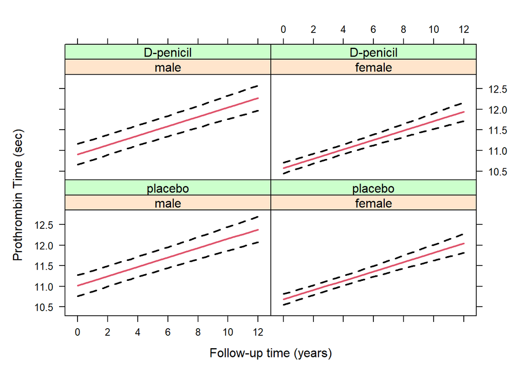

```r
xyplot(pred + low + upp ~ year | sex*drug,
       data = effectPlotData(fm_3ML_noIntLin, newDF, pbc2),
       lty = c(1, 2, 2), col = c(2, 1, 1), lwd = 2, type = "l",
       xlab = "Follow-up time (years)", ylab = "Prothrombin Time (sec)")
```

## Question 9

To investigate whether the assumption for the residuals terms are satisfied we can inspect the scatterplots of the residuals versus the fitted values. As we have seen in Section 2.11, there are two types of residuals we can compute the *standardized residuals* and the *normalized residuals*. We shart with the standardized residuals and we produce the overall scatteplot of these residuals versus the fitted values, and then we split per sex and treatment allocation:

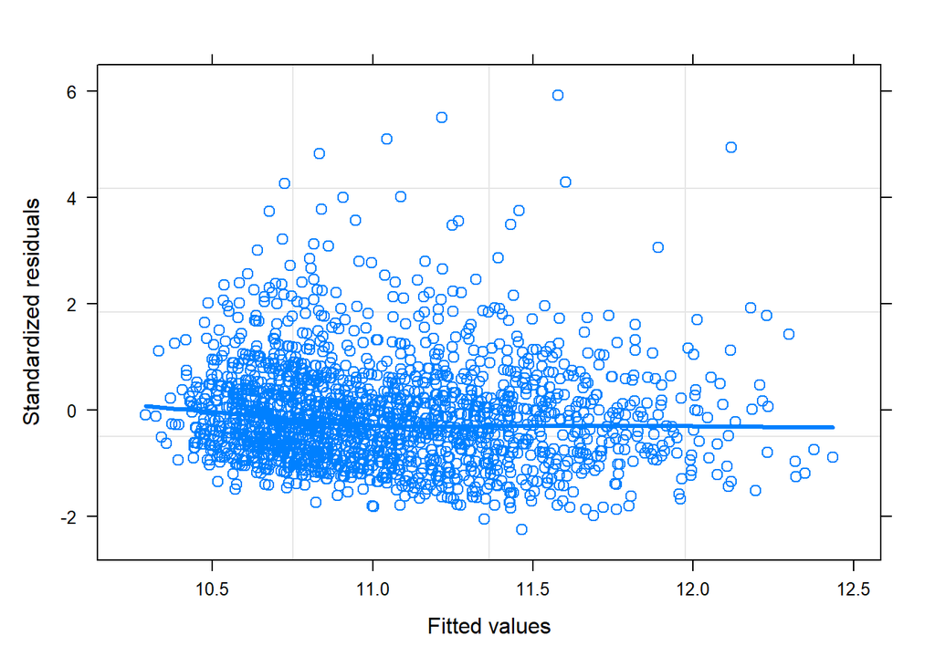

```r
plot(fm_3ML_noIntLin, resid(., type = "p") ~ fitted(.),
     type = c("p", "smooth"), lwd = 3)
```

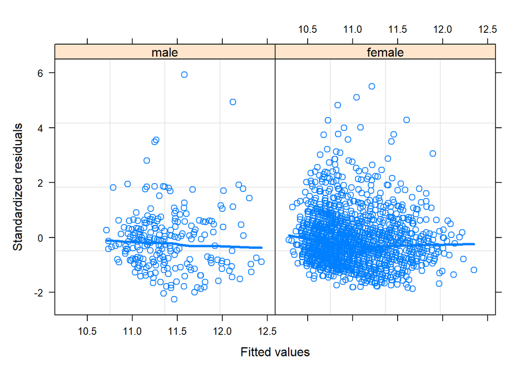

```r
plot(fm_3ML_noIntLin, resid(., type = "p") ~ fitted(.) | sex,
     type = c("p", "smooth"), lwd = 3)
```

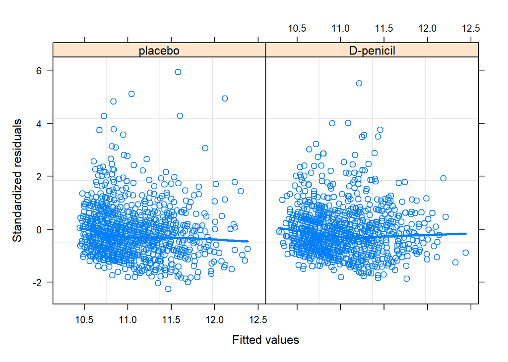

```r
plot(fm_3ML_noIntLin, resid(., type = "p") ~ fitted(.) | drug,
     type = c("p", "smooth"), lwd = 3)
```

We continue by producing the same scatterplots but for the normalized residuals now:

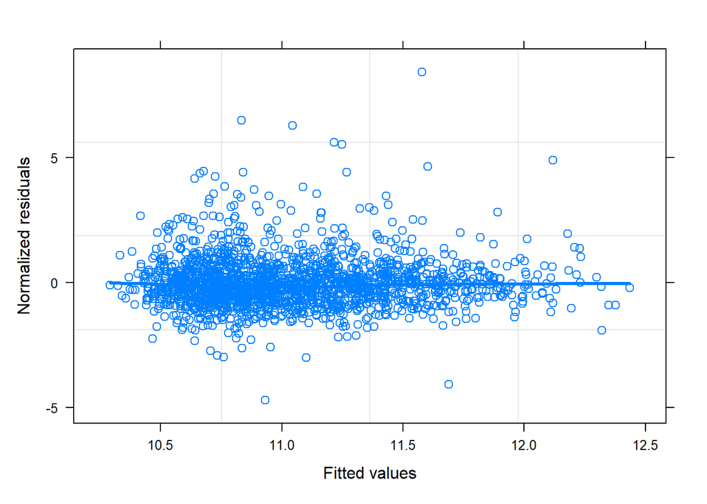

```r
plot(fm_3ML_noIntLin, resid(., type = "n") ~ fitted(.),
     type = c("p", "smooth"), lwd = 3)
```

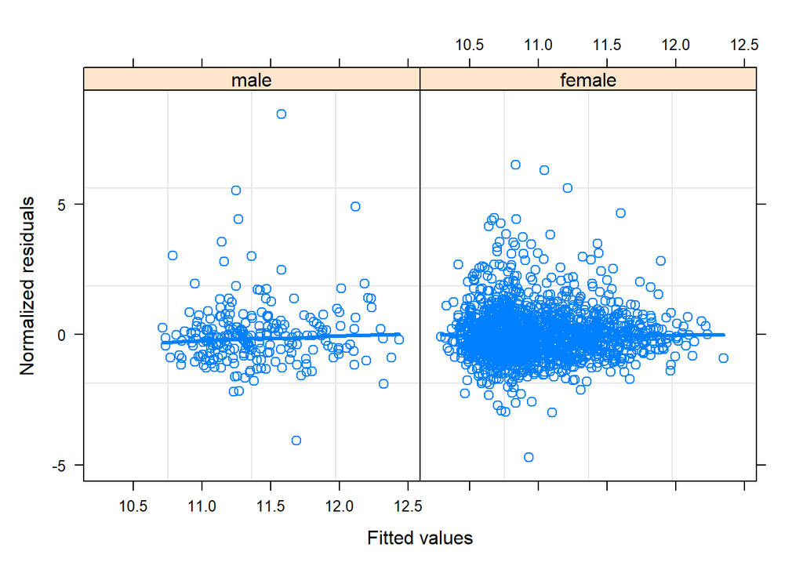

```r
plot(fm_3ML_noIntLin, resid(., type = "n") ~ fitted(.) | sex,
     type = c("p", "smooth"), lwd = 3)
```

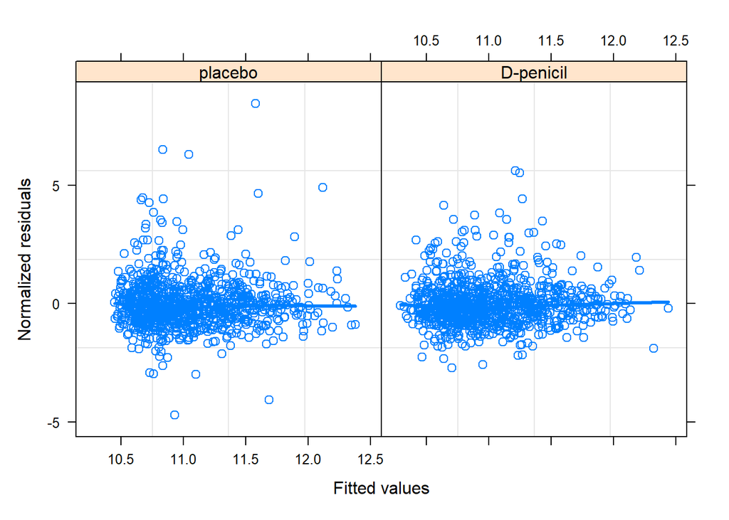

```r
plot(fm_3ML_noIntLin, resid(., type = "n") ~ fitted(.) | drug,
     type = c("p", "smooth"), lwd = 3)
```

From all six plots we can observe that there still some outlying observations, but the general shapes do not suggest any serious misfit.